# Data-Driven Employee Retention: Leveraging Survival and Uplift Modeling for Strategic HR Insights

Quan Nguyen Hien

2024-04-21

# Introduction

In today’s fast-paced work environments, retaining employees has become a top priority for organizations worldwide. When a team member leaves the company, this not only causes a disruption in workflows, but also leads to an increase in terms of costs that need to be spent on recruitment, training as well as necessary time to get along with other team members that decrease the overall productivity. As there’s a rising demand on identifying and tackling this challenge, many companies are increasingly turning to sophisticated analytical methods to uncover the underlying reasons behind employee turnover and allows for the development of predictive models to anticipate future departures. In this project, I will focus on using Survival Analysis for this problem with its advantages in modeling the employee’s risk of quitting from the companies based on a real dataset provided by Edward Babushkin, who examines the importance of this method instead of using logistic regression for risk assessment.

# Data Information

## Data Overview

The dataset contains the following variables:

```r
# Read the data
emp_df <- read.csv("employee/turnover.csv")
```

```r
# Show the data's structure
str(emp_df)
```

```
## 'data.frame':    1129 obs. of  16 variables:
##  $ stag        : num  7.03 22.97 15.93 15.93 8.41 ...
##  $ event       : int  1 1 1 1 1 1 1 1 1 1 ...
##  $ gender      : chr  "m" "m" "f" "f" ...
##  $ age         : num  35 33 35 35 32 42 42 28 29 30 ...
##  $ industry    : chr  "Banks" "Banks" "PowerGeneration" "PowerGeneration" ...
##  $ profession  : chr  "HR" "HR" "HR" "HR" ...
##  $ traffic     : chr  "rabrecNErab" "empjs" "rabrecNErab" "rabrecNErab" ...
##  $ coach       : chr  "no" "no" "no" "no" ...
##  $ head_gender : chr  "f" "m" "m" "m" ...
##  $ greywage    : chr  "white" "white" "white" "white" ...
##  $ way         : chr  "bus" "bus" "bus" "bus" ...
##  $ extraversion: num  6.2 6.2 6.2 5.4 3 6.2 6.2 3.8 8.6 5.4 ...
##  $ independ    : num  4.1 4.1 6.2 7.6 4.1 6.2 6.2 5.5 6.9 5.5 ...
##  $ selfcontrol : num  5.7 5.7 2.6 4.9 8 4.1 4.1 8 2.6 3.3 ...
##  $ anxiety     : num  7.1 7.1 4.8 2.5 7.1 5.6 5.6 4 4 7.9 ...
##  $ novator     : num  8.3 8.3 8.3 6.7 3.7 6.7 6.7 4.4 7.5 8.3 ...
```

```r
# Sample the first 6 rows of the data
head(emp_df)
```

```
##        stag event gender age        industry profession     traffic coach
## 1  7.030801     1      m  35           Banks         HR rabrecNErab    no
## 2 22.965092     1      m  33           Banks         HR       empjs    no
## 3 15.934292     1      f  35 PowerGeneration         HR rabrecNErab    no
## 4 15.934292     1      f  35 PowerGeneration         HR rabrecNErab    no
## 5  8.410678     1      m  32          Retail Commercial       youjs   yes
## 6  8.969199     1      f  42     manufacture         HR       empjs   yes
##   head_gender greywage way extraversion independ selfcontrol anxiety novator
## 1           f    white bus          6.2      4.1         5.7     7.1     8.3
## 2           m    white bus          6.2      4.1         5.7     7.1     8.3
## 3           m    white bus          6.2      6.2         2.6     4.8     8.3
## 4           m    white bus          5.4      7.6         4.9     2.5     6.7
## 5           f    white bus          3.0      4.1         8.0     7.1     3.7
## 6           m    white bus          6.2      6.2         4.1     5.6     6.7
```

## Data Pre-processing

```r
# Rename the columns for better representation
colnames(emp_df) <- c("exp","event","self_gender","age","field","prof","route","coach","head_gender","wage","trans","score_extro","score_idpt","score_selfctrl","score_anx","score_innov")
```

```r
# Categorize feature based on their data types
cat_features <- c("self_gender", "field", "prof", "route", "coach", "head_gender", "wage", "trans")
num_features <- colnames(emp_df)[!c(colnames(emp_df) %in% cat_features)]
```

```r
num_features
```

```
## [1] "exp"            "event"          "age"            "score_extro"
## [5] "score_idpt"     "score_selfctrl" "score_anx"      "score_innov"
```

First, we can investigate the unique values of each categorical variable.

```r
# Unique values of each categorical features
for (col in cat_features){
  print(table(emp_df[col]))
}
```

```
## self_gender
##   f   m
## 853 276
## field
##          HoReCa     Agriculture           Banks        Building         Consult
##              11              15             114              41              74
##             etc              IT     manufacture          Mining          Pharma
##              94             122             145              24              20
## PowerGeneration      RealEstate          Retail           State         Telecom
##              38              13             289              55              36
##       transport
##              38
## prof
##          Finan\xf1e          Accounting BusinessDevelopment          Commercial
##                  17                  10                  27                  23
##             Consult            Engineer                 etc                  HR
##                  25                  15                  37                 757
##                  IT                 Law              manage           Marketing
##                  74                   7                  22                  31
##                  PR               Sales            Teaching
##                   6                  66                  12
## route
##      advert       empjs     friends          KA rabrecNErab    recNErab
##          33         248         118          67         211          39
##     referal       youjs
##          95         318
## coach
## my head      no     yes
##     314     683     132
## head_gender
##   f   m
## 545 584
## wage
##  grey white
##   127  1002
## trans
##  bus  car foot
##  681  331  117
```

As we can see from a sneek peak of the dataset, during the data collection process, some typographical errors were introduced (e.g., Finance is recorded as **Finan1e**), which could potentially complicate the analysis and interpretation. To ensure accurate results and clear insights, it is necessary to address these inconsistencies. Additionally, we can refine and re-categorize certain values for easier interpretation based on the provided assumptions. Below are some suggested re-factorings for the categorical variables:

```r
emp_df <- emp_df %>%
  mutate(prof = if_else(prof == "Finan\xf1e", "Finance", prof))

emp_df %>% mutate(field = factor(case_match(
  field,
  .default="others",
  "Retail" ~ "retail",
  "manufacture" ~ "manufacture",
  "IT" ~ "IT",
  "Banks" ~ "finance"))) -> emp_df

emp_df %>% mutate(route = factor(case_match(
  route,
  .default="others",
  "empjs" ~ "jobsite_resume",
  "friends" ~ "friends",
  c("referal", "rabrecNErab", "recNErab") ~ "recommend",
  "youjs" ~ "jobsite_apply"))) -> emp_df
```

```r
for (col in cat_features){
  print(table(emp_df[col]))
}
```

```
## self_gender
##   f   m
## 853 276
## field
##     finance          IT manufacture      others      retail
##         114         122         145         459         289
## prof
##          Accounting BusinessDevelopment          Commercial             Consult
##                  10                  27                  23                  25
##            Engineer                 etc             Finance                  HR
##                  15                  37                  17                 757
##                  IT                 Law              manage           Marketing
##                  74                   7                  22                  31
##                  PR               Sales            Teaching
##                   6                  66                  12
## route
##        friends  jobsite_apply jobsite_resume         others      recommend
##            118            318            248            100            345
## coach
## my head      no     yes
##     314     683     132
## head_gender
##   f   m
## 545 584
## wage
##  grey white
##   127  1002
## trans
##  bus  car foot
##  681  331  117
```

```r
# Convert all categorical features to factor data type
for (col in cat_features) {
  emp_df[[col]] <- as.factor(emp_df[[col]])
}
```

```r
## Change appropriate reference group:
emp_df$field <- relevel(emp_df$field, ref = "others")
emp_df$route <- relevel(emp_df$route, ref = "others")
emp_df$coach <- relevel(emp_df$coach, ref = "no")
emp_df$wage <- relevel(emp_df$wage, ref = "grey")
emp_df$trans <- relevel(emp_df$trans, ref = "bus")
```

# Exploratory Data Analysis

In this section, we will explore the dataset to gain initial insights and identify patterns, trends, and potential anomalies. Through descriptive statistics and visualizations, we will highlight key features and prepare the dataset for more advanced analysis.

```r
# Summary statistics for numerical features
summary(emp_df[num_features])
```

```
##       exp               event             age         score_extro
##  Min.   :  0.3942   Min.   :0.0000   Min.   :18.00   Min.   : 1.000
##  1st Qu.: 11.7289   1st Qu.:0.0000   1st Qu.:26.00   1st Qu.: 4.600
##  Median : 24.3450   Median :1.0000   Median :30.00   Median : 5.400
##  Mean   : 36.6275   Mean   :0.5058   Mean   :31.07   Mean   : 5.592
##  3rd Qu.: 51.3183   3rd Qu.:1.0000   3rd Qu.:36.00   3rd Qu.: 7.000
##  Max.   :179.4497   Max.   :1.0000   Max.   :58.00   Max.   :10.000
##    score_idpt     score_selfctrl     score_anx       score_innov
##  Min.   : 1.000   Min.   : 1.000   Min.   : 1.700   Min.   : 1.00
##  1st Qu.: 4.100   1st Qu.: 4.100   1st Qu.: 4.800   1st Qu.: 4.40
##  Median : 5.500   Median : 5.700   Median : 5.600   Median : 6.00
##  Mean   : 5.478   Mean   : 5.597   Mean   : 5.666   Mean   : 5.88
##  3rd Qu.: 6.900   3rd Qu.: 7.200   3rd Qu.: 7.100   3rd Qu.: 7.50
##  Max.   :10.000   Max.   :10.000   Max.   :10.000   Max.   :10.00
```

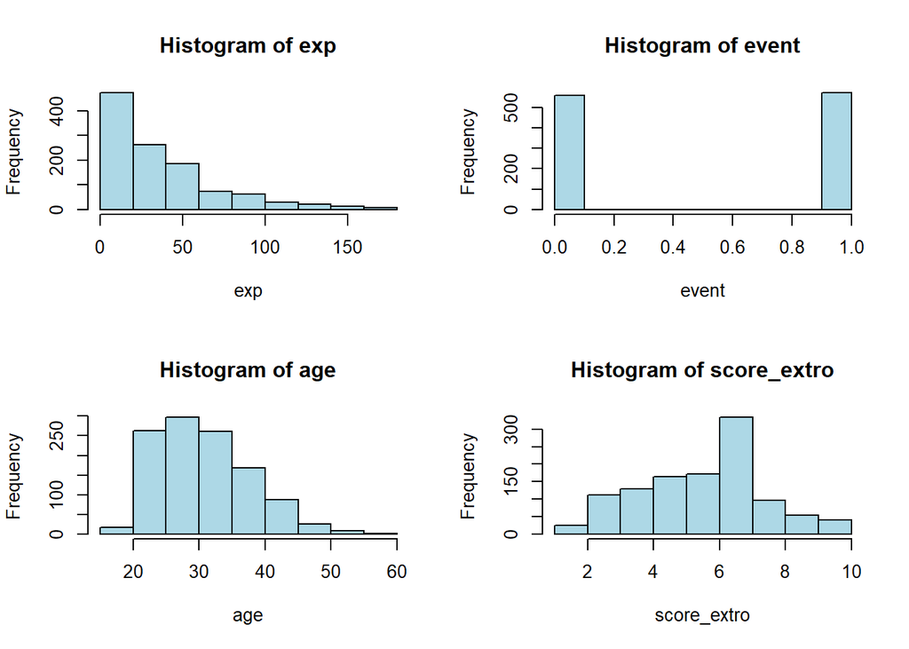

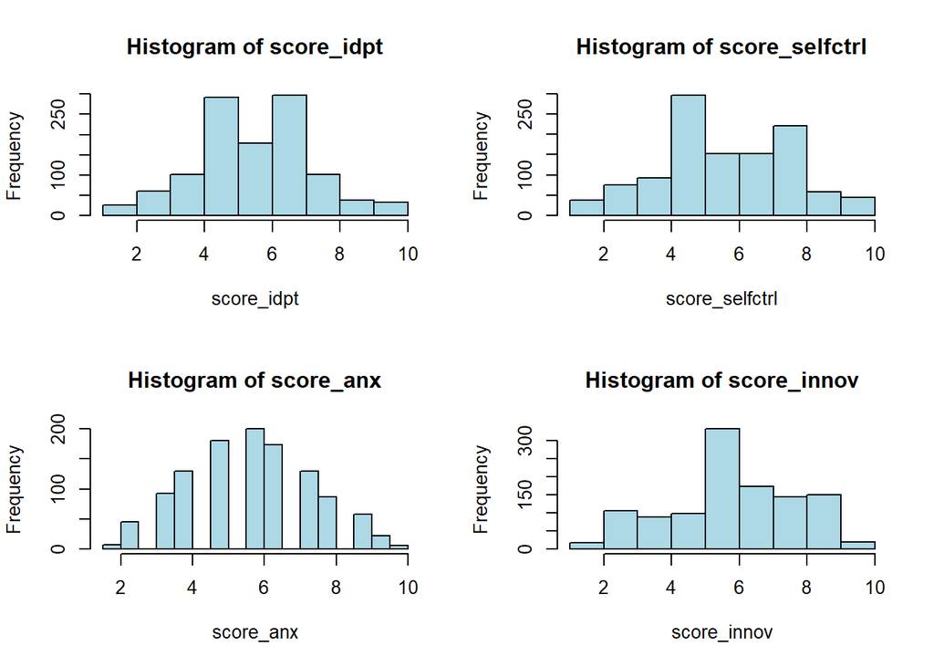

```r
# Set up the plot window to display multiple plots
par(mfrow = c(2, 2))

for (column in num_features) {
  hist(emp_df[[column]], main = paste("Histogram of", column), xlab = column, col = "lightblue")
}
```

We will further look into the distribution of response variable **Experience (exp)** for non-censored as well censored data:

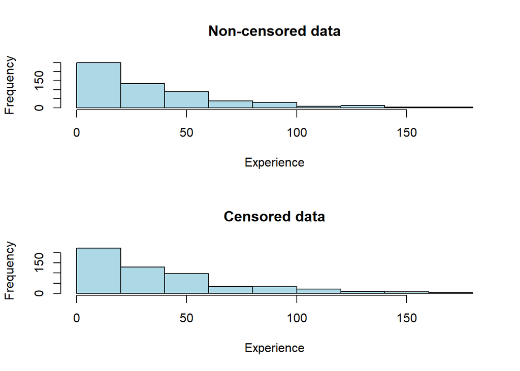

```r
par(mfrow=c(2,1))
hist(as.matrix(emp_df %>% filter(event==1) %>%  pull(exp)), xlab="Experience", main="Non-censored data",col = "lightblue")

hist(as.matrix(emp_df %>% filter(event==0) %>% pull(exp)), xlab="Experience", main="Censored data", col = "lightblue")
```

```r
long_df <- pivot_longer(emp_df, cols =c(self_gender, field, prof, route, coach, head_gender, wage, trans), names_to = "Category", values_to = "Value")
cat_factors <- c("self_gender", "field", "prof", "route", "coach", "head_gender", "wage", "trans")

# Loop through each categorical variable and create a plot
plots <- lapply(cat_factors, function(cat) {
  ggplot(data = filter(long_df, Category == cat), aes(x = Value, fill = Value)) +
    geom_bar() +
    facet_wrap(~event, nrow = 2) +
    labs(title = paste("Distribution of", cat, "by Event (censored or not)"), x = cat, y = "Count") +
    theme_minimal() +
    theme(axis.text.x = element_text(angle = 45, hjust = 1))
})
```

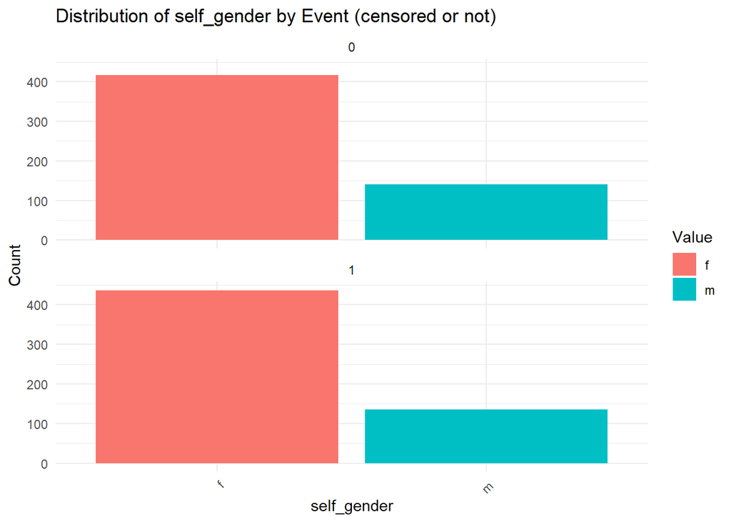

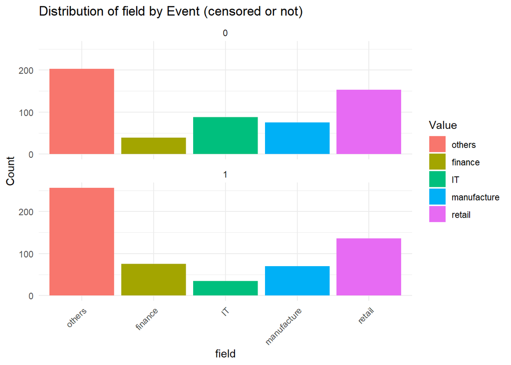

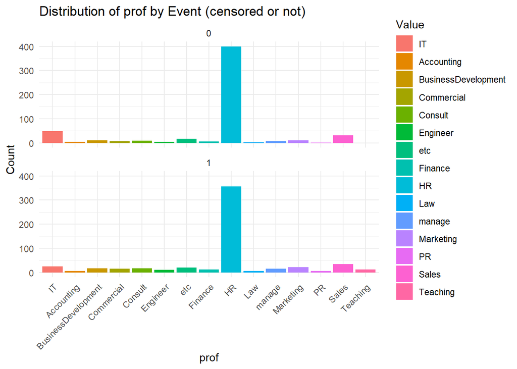

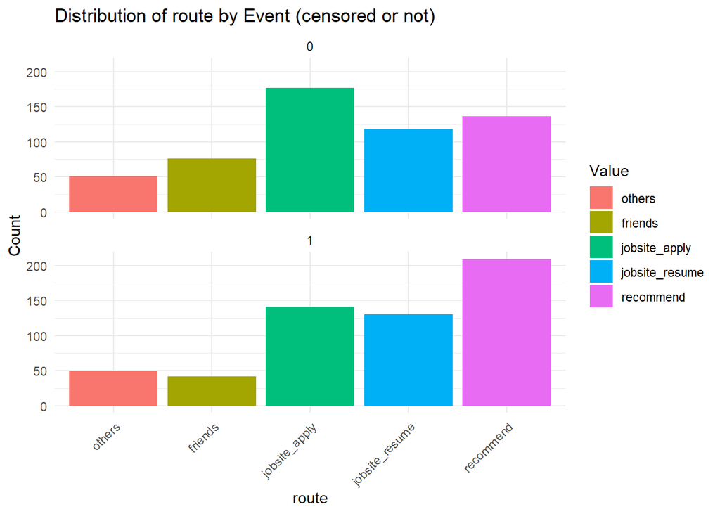

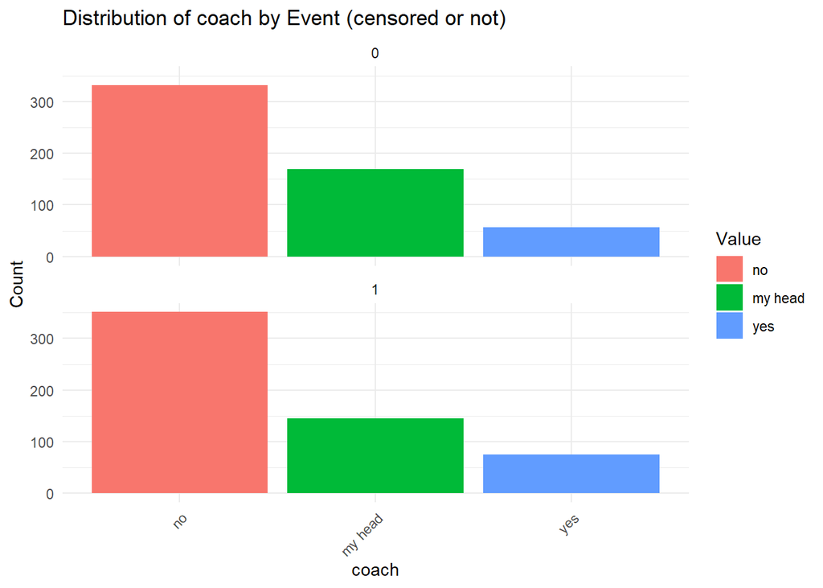

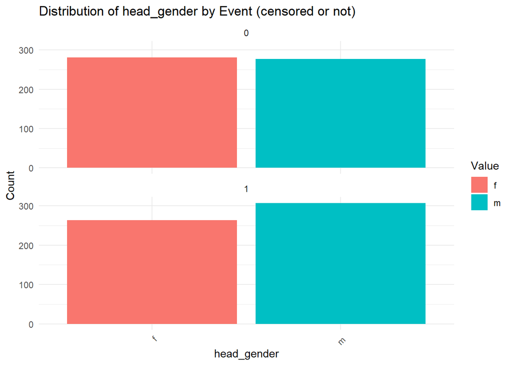

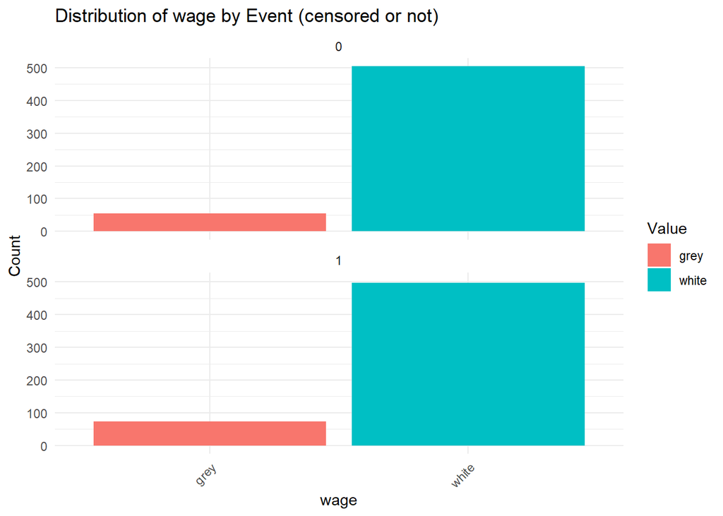

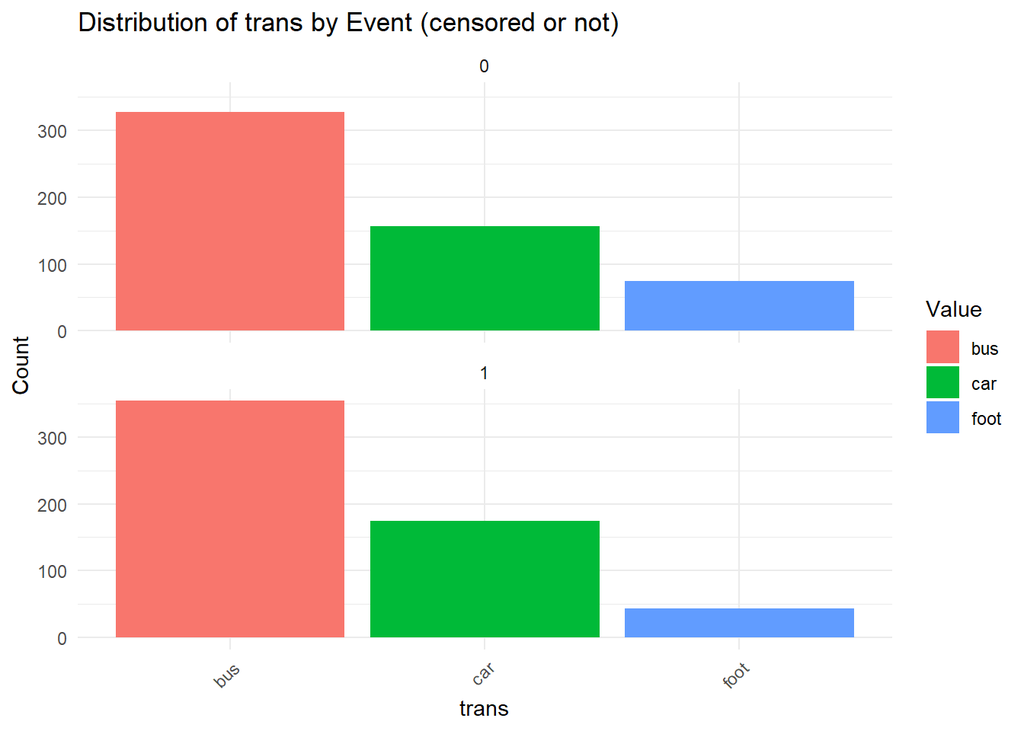

```r
plots
```

## Non-parametric Methods (Kaplan-Meier):

First, we will investigate whether different groups within the dataset exhibit variations in retention rates (also referred to as survival rates in the context of survival analysis). To do this, we will calculate Kaplan-Meier estimates for each group, enabling a comparison of their retention rates. Additionally, we will conduct a log-rank test to determine whether the observed differences between the groups are statistically significant with predetermined significance level of 0.05.

```r
mod <- survfit(Surv(exp, event)~self_gender, data = emp_df)
plot1 <- ggsurvplot(mod, data = emp_df,
                     conf.int = FALSE,
                     ggtheme = theme_minimal(),
                     pval = TRUE,
                     pval.method = TRUE) +
          ggtitle("Retention curve by Employee's Gender")

mod <- survfit(Surv(exp, event)~field, data = emp_df)
plot2 <- ggsurvplot(mod, data = emp_df,
                     conf.int = FALSE,
                     ggtheme = theme_minimal(),
                     pval = TRUE,
                     pval.method = TRUE) +
          ggtitle("Retention curve by Employee's Industry sector")


mod <- survfit(Surv(exp, event)~prof, data = emp_df)
plot3 <- ggsurvplot(mod, data = emp_df,
                     conf.int = FALSE,
                     ggtheme = theme_minimal(),
                     pval = TRUE,
                     pval.method = TRUE) +
          ggtitle("Retention curve by Employee's Profession")

mod <- survfit(Surv(exp, event)~route, data = emp_df)
plot4 <- ggsurvplot(mod, data = emp_df,
                     conf.int = FALSE,
                     ggtheme = theme_minimal(),
                     pval = TRUE,
                     pval.method = TRUE) +
          ggtitle("Retention curve by Employee's Source came to the Company")

mod <- survfit(Surv(exp, event)~coach, data = emp_df)
plot5 <- ggsurvplot(mod, data = emp_df,
                     conf.int = FALSE,
                     ggtheme = theme_minimal(),
                     pval = TRUE,
                     pval.method = TRUE) +
          ggtitle("Retention curve by Employee's Coaching/Training availability")

mod <- survfit(Surv(exp, event)~head_gender, data = emp_df)
plot6 <- ggsurvplot(mod, data = emp_df,
                     conf.int = FALSE,
                     ggtheme = theme_minimal(),
                     pval = TRUE,
                     pval.method = TRUE) +
          ggtitle("Retention curve by Gender of the employee's supervisor")

mod <- survfit(Surv(exp, event)~wage, data = emp_df)
plot7 <- ggsurvplot(mod, data = emp_df,
                     conf.int = FALSE,
                     ggtheme = theme_minimal(),
                     pval = TRUE,
                     pval.method = TRUE) +
          ggtitle("Retention curve by Employee's Wage (Tax reported or not)")


mod <- survfit(Surv(exp, event)~trans, data = emp_df)
plot8 <- ggsurvplot(mod, data = emp_df,
                     conf.int = FALSE,
                     ggtheme = theme_minimal(),
                     pval = TRUE,
                     pval.method = TRUE) +
          ggtitle("Retention curve by Employee's mode of Transportation")
```

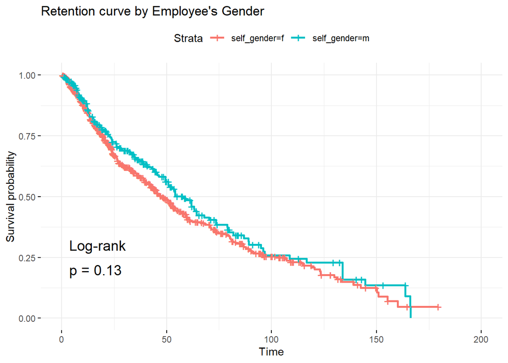

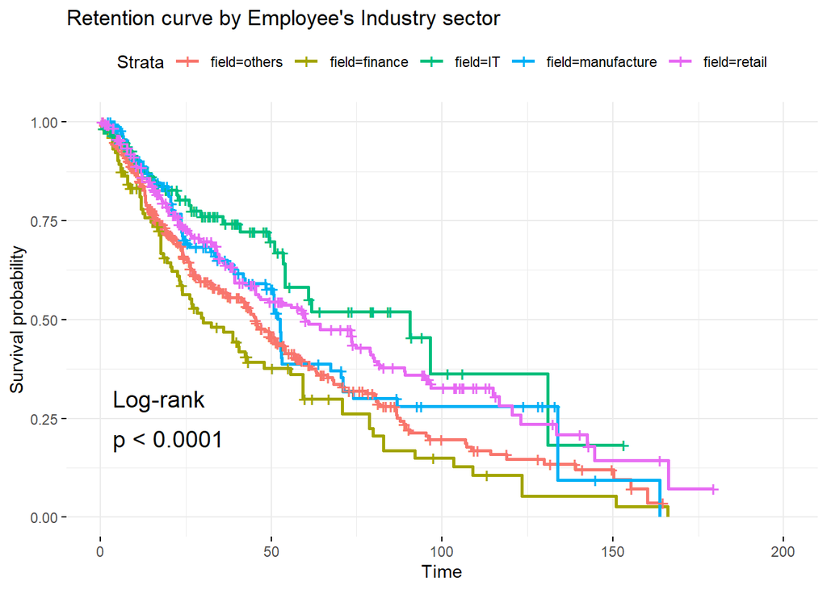

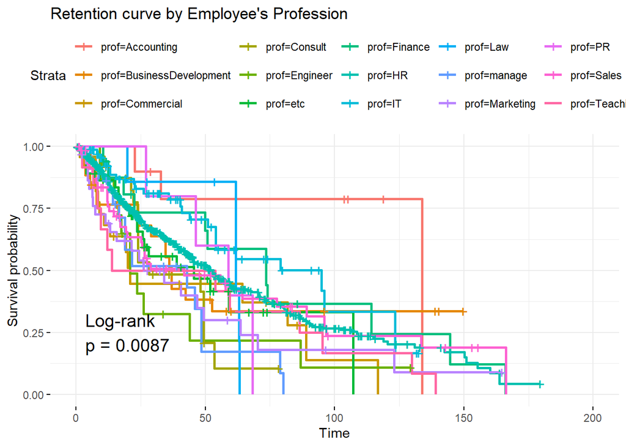

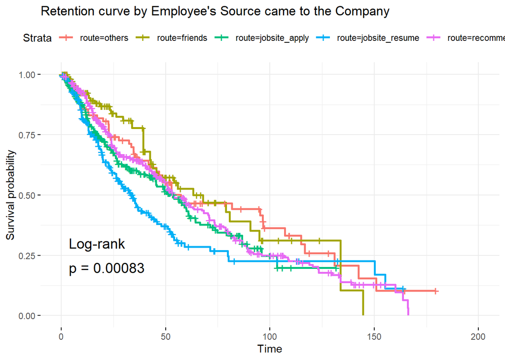

```r
plot1$plot; plot2$plot; plot3$plot; plot4$plot;
```

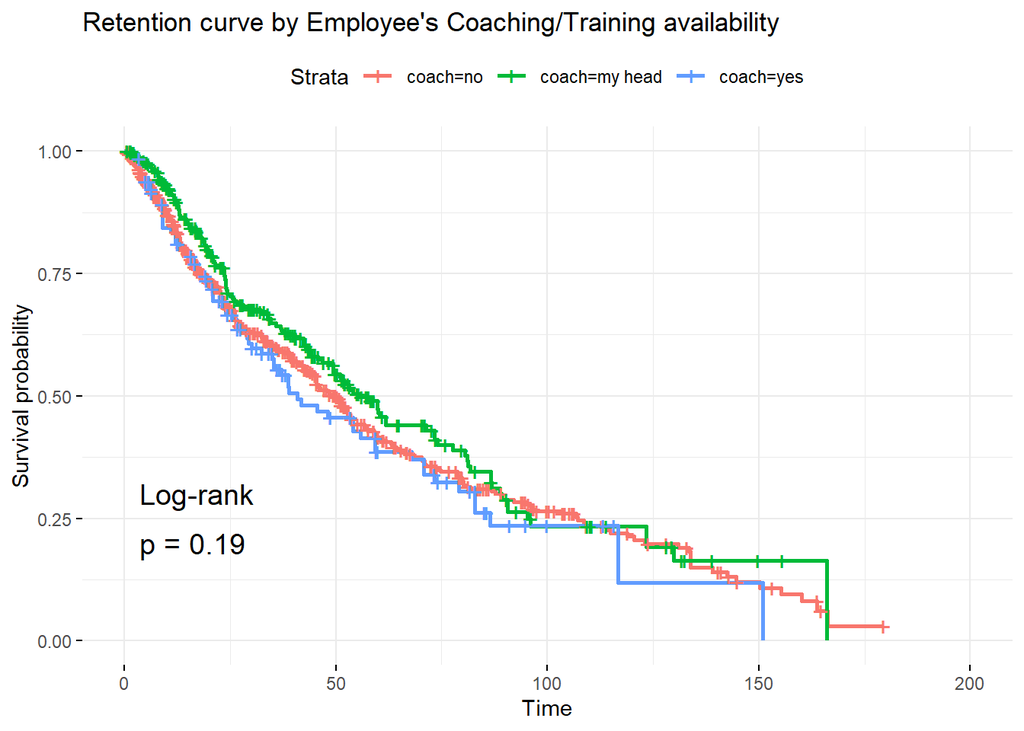

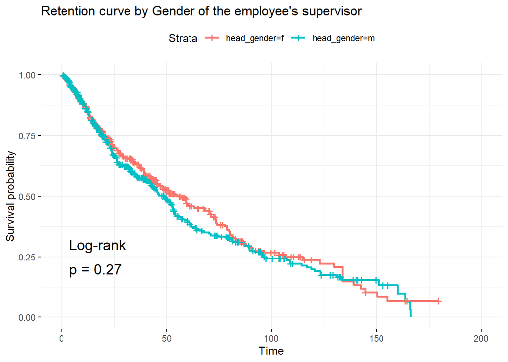

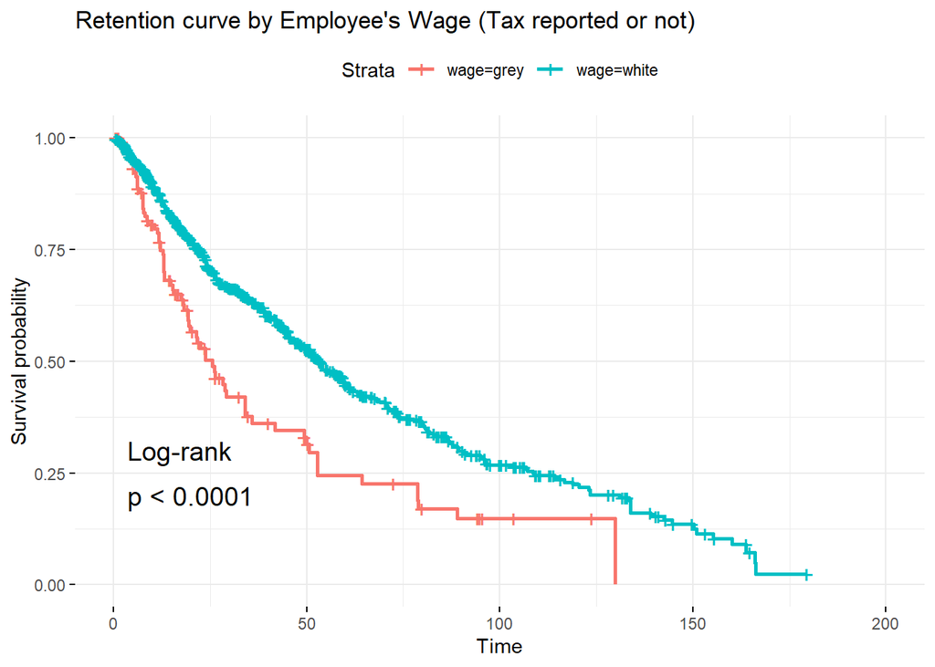

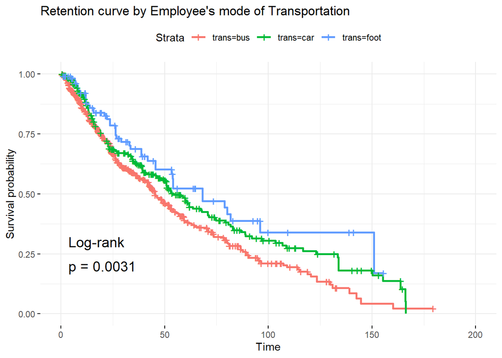

```r
plot5$plot; plot6$plot; plot7$plot; plot8$plot
```

Based on the following results, we can confirm that there’s difference in terms of retention rate for the following variable: - **Industry Sector (field)** - **Profession (prof)** - **Source came to Company (route)** - **Wage tax authorized or not (wage)** - **Mode of Transportation (trans)**

# Data Modelling

## Parametric Survival Model

### Find Parametric Distribution

We need to determine which distribution the **Experience (exp)** follows before applying parametric method such as Accelerated Failure Time (AFT) model.We will examine two popular assumed form of **Experience (exp)** Weibull, Exponential distribution.

```r
library(goftest)
fitdistr(emp_df$exp, "weibull")
```

```
##       shape         scale
##    1.08272153   37.78782884
##  ( 0.02503311) ( 1.09608991)
```

```r
weibullCDF <- function(x, shape, scale) {
  1 - exp(- (x / scale)^shape)
}
# Estimate parameters if not known
shape_hat <- 1.08272153
scale_hat <- 37.78782884

# Perform the Anderson-Darling test for Weibull
result <- ad.test(emp_df$exp, function(x) weibullCDF(x, shape = shape_hat, scale = scale_hat))

# Print the test result
print(result)
```

```
##
##  Anderson-Darling test of goodness-of-fit
##  Null hypothesis: distribution 'function(x) weibullCDF(x, shape =
##  shape_hat, scale = scale_hat)'
##  Parameters assumed to be fixed
##
## data:  emp_df$exp
## An = 1.3391, p-value = 0.22
```

```r
# Fit exponential model
exp_model <- survreg(Surv(exp, event) ~ 1, data = emp_df, dist = 'exponential')
lambda_hat <- 1 / exp_model$scale  # Rate parameter

# Anderson-Darling test for exponentiality
result <- ad.test(emp_df$exp, "pexp", rate = lambda_hat)

# Print the result
print(result)
```

```
##
##  Anderson-Darling test of goodness-of-fit
##  Null hypothesis: exponential distribution
##  with parameter rate = 1
##  Parameters assumed to be fixed
##
## data:  emp_df$exp
## An = Inf, p-value = 5.314e-07
```

After fitting the exponential model with a scale parameter of 1, we obtain a p-value of less than 0.05, leading us to reject the null hypothesis that the exponential distribution with a rate parameter of 1 is appropriate for this model. Next, we test the Weibull distribution, using the estimated scale and shape parameters derived from the exp variable in the dataset. The p-value from the Anderson-Darling Goodness-of-Fit test is 0.22, indicating that we fail to reject the null hypothesis. Thus, we proceed with the Weibull distribution as the assumption for the AFT model as below.

We will define the base model that included all predictors, then perform step-wise regression for finding the best combinations of predictors (based on the criteria of lowest AIC)

```r
base_mod<-survreg(Surv(exp, event)~.,data = emp_df, dist = "weibull")
step(base_mod)
```

```
## Start:  AIC=5956.48
## Surv(exp, event) ~ self_gender + age + field + prof + route +
##     coach + head_gender + wage + trans + score_extro + score_idpt +
##     score_selfctrl + score_anx + score_innov
##
##                  Df    AIC
## - score_innov     1 5954.5
## - self_gender     1 5954.7
## - score_idpt      1 5954.7
## - score_extro     1 5955.0
## - head_gender     1 5955.4
## - coach           2 5955.9
## <none>              5956.5
## - score_selfctrl  1 5957.0
## - prof           14 5957.7
## - score_anx       1 5957.8
## - trans           2 5961.3
## - age             1 5965.0
## - wage            1 5966.6
## - field           4 5979.1
## - route           4 5981.4
##
## Step:  AIC=5954.5
## Surv(exp, event) ~ self_gender + age + field + prof + route +
##     coach + head_gender + wage + trans + score_extro + score_idpt +
##     score_selfctrl + score_anx
##
##                  Df    AIC
## - self_gender     1 5952.7
## - score_idpt      1 5952.8
## - score_extro     1 5953.0
## - head_gender     1 5953.4
## - coach           2 5953.9
## <none>              5954.5
## - score_selfctrl  1 5955.4
## - prof           14 5955.7
## - score_anx       1 5956.0
## - trans           2 5959.3
## - age             1 5963.0
## - wage            1 5964.6
```

[output cut: 73 more lines]

```
##
## Step:  AIC=5948.76
## Surv(exp, event) ~ age + field + prof + route + wage + trans +
##     score_selfctrl + score_anx
##
##                  Df    AIC
## <none>              5948.8
## - prof           14 5951.4
## - score_anx       1 5952.8
## - trans           2 5953.6
## - score_selfctrl  1 5955.6
## - age             1 5959.3
## - wage            1 5959.5
## - field           4 5971.9
## - route           4 5972.6
```

```
## Call:
## survreg(formula = Surv(exp, event) ~ age + field + prof + route +
##     wage + trans + score_selfctrl + score_anx, data = emp_df,
##     dist = "weibull")
##
## Coefficients:
##             (Intercept)                     age            fieldfinance
##             4.290954476            -0.019667910            -0.331611466
##                 fieldIT        fieldmanufacture             fieldretail
##             0.460216178             0.133770055             0.294066748
## profBusinessDevelopment          profCommercial             profConsult
##            -0.331475026            -0.816549442            -0.746764123
##            profEngineer                 profetc             profFinance
##            -0.771198398            -0.477817033            -0.259299256
##                  profHR                  profIT                 profLaw
##            -0.256849028            -0.025093874            -0.447873317
##              profmanage           profMarketing                  profPR
##            -1.096702978            -0.734964234            -0.755396244
##               profSales            profTeaching            routefriends
##            -0.503692717            -0.460266310             0.005788691
##      routejobsite_apply     routejobsite_resume          routerecommend
##            -0.403216519            -0.652138777            -0.191406994
##               wagewhite                transcar               transfoot
##             0.424160983             0.164941113             0.362512604
##          score_selfctrl               score_anx
##             0.056083991             0.053587423
##
## Scale= 0.8594605
##
## Loglik(model)= -2944.4   Loglik(intercept only)= -3014.3
##  Chisq= 139.79 on 28 degrees of freedom, p= <2e-16
## n= 1129
```

```r
best_mod <- survreg(formula = Surv(exp, event) ~ age + field + prof + route +
    wage + trans + score_selfctrl + score_anx, data = emp_df,
    dist = "weibull")
summary(best_mod)
```

```
##
## Call:
## survreg(formula = Surv(exp, event) ~ age + field + prof + route +
##     wage + trans + score_selfctrl + score_anx, data = emp_df,
##     dist = "weibull")
##                            Value Std. Error     z       p
## (Intercept)              4.29095    0.46798  9.17 < 2e-16
## age                     -0.01967    0.00544 -3.61 0.00030
## fieldfinance            -0.33161    0.11902 -2.79 0.00533
## fieldIT                  0.46022    0.16580  2.78 0.00551
## fieldmanufacture         0.13377    0.12396  1.08 0.28054
## fieldretail              0.29407    0.09774  3.01 0.00262
## profBusinessDevelopment -0.33148    0.42033 -0.79 0.43034
## profCommercial          -0.81655    0.42315 -1.93 0.05365
## profConsult             -0.74676    0.42241 -1.77 0.07708
## profEngineer            -0.77120    0.44142 -1.75 0.08062
## profetc                 -0.47782    0.40574 -1.18 0.23894
## profFinance             -0.25930    0.43531 -0.60 0.55140
## profHR                  -0.25685    0.35998 -0.71 0.47553
## profIT                  -0.02509    0.40052 -0.06 0.95004
## profLaw                 -0.44787    0.52706 -0.85 0.39546
## profmanage              -1.09670    0.41998 -2.61 0.00902
## profMarketing           -0.73496    0.40380 -1.82 0.06874
## profPR                  -0.75540    0.53079 -1.42 0.15470
## profSales               -0.50369    0.38679 -1.30 0.19284
## profTeaching            -0.46027    0.44598 -1.03 0.30206
## routefriends             0.00579    0.18479  0.03 0.97501
## routejobsite_apply      -0.40322    0.14682 -2.75 0.00603
## routejobsite_resume     -0.65214    0.14948 -4.36 1.3e-05
## routerecommend          -0.19141    0.13977 -1.37 0.17086
## wagewhite                0.42416    0.11255  3.77 0.00016
## transcar                 0.16494    0.08429  1.96 0.05037
## transfoot                0.36251    0.14416  2.51 0.01192
## score_selfctrl           0.05608    0.01881  2.98 0.00287
## score_anx                0.05359    0.02189  2.45 0.01436
## Log(scale)              -0.15145    0.03298 -4.59 4.4e-06
##
## Scale= 0.859
##
## Weibull distribution
## Loglik(model)= -2944.4   Loglik(intercept only)= -3014.3
##  Chisq= 139.79 on 28 degrees of freedom, p= 8.2e-17
## Number of Newton-Raphson Iterations: 7
## n= 1129
```

We can see some interesting insights based on the significant variables, the following would show all hazard ratios for each estimate obtained from the model and some interpretations of each significant factor based on the results, controlling other factors remain the same.

```r
haz_rate <- exp(best_mod$coefficients)
haz_rate
```

```
##             (Intercept)                     age            fieldfinance
##              73.0361465               0.9805242               0.7177661
##                 fieldIT        fieldmanufacture             fieldretail
##               1.5844165               1.1431299               1.3418735
## profBusinessDevelopment          profCommercial             profConsult
##               0.7178641               0.4419540               0.4738975
##            profEngineer                 profetc             profFinance
##               0.4624585               0.6201357               0.7715921
##                  profHR                  profIT                 profLaw
##               0.7734850               0.9752184               0.6389856
##              profmanage           profMarketing                  profPR
##               0.3339704               0.4795226               0.4698244
##               profSales            profTeaching            routefriends
##               0.6042950               0.6311156               1.0058055
##      routejobsite_apply     routejobsite_resume          routerecommend
##               0.6681674               0.5209304               0.8257964
##               wagewhite                transcar               transfoot
##               1.5283076               1.1793237               1.4369353
##          score_selfctrl               score_anx
##               1.0576865               1.0550492
```

Individuals working in the IT field tend to stay at their companies 2.2 times longer than those in finance. Similarly, individuals who apply for jobs through job sites or resumes generally have shorter tenures compared to those who secure positions through referrals from friends. Additionally, employees receiving fully taxed wages (white wages) tend to remain at their companies 52% longer than those receiving untaxed (gray) wages, indicating a longer duration of employment. Higher self-control scores are also associated with longer tenure. Interestingly, individuals who walk to work tend to stay 43.7% longer at their companies compared to those who primarily commute by bus.

## Cox Proportional Hazards model (semi-parametric)

In order to derive meaningful conclusions about employee retention with a robust handling of censored data that can serve as a predictive model, we can perform Cox proportional Hazard model (semi-parametric model).

```r
cox_base_mod <- coxph(Surv(exp, event)~.,data = emp_df)
step(cox_base_mod)
```

```
## Start:  AIC=6871.14
## Surv(exp, event) ~ self_gender + age + field + prof + route +
##     coach + head_gender + wage + trans + score_extro + score_idpt +
##     score_selfctrl + score_anx + score_innov
##
##                  Df    AIC
## - score_innov     1 6869.1
## - score_idpt      1 6869.3
## - self_gender     1 6869.5
## - score_extro     1 6869.8
## - head_gender     1 6869.9
## - coach           2 6870.3
## - prof           14 6870.7
## - score_selfctrl  1 6871.1
## <none>              6871.1
## - score_anx       1 6872.0
## - trans           2 6876.6
## - age             1 6880.0
## - wage            1 6881.1
## - field           4 6892.5
## - route           4 6892.7
##
## Step:  AIC=6869.15
## Surv(exp, event) ~ self_gender + age + field + prof + route +
##     coach + head_gender + wage + trans + score_extro + score_idpt +
##     score_selfctrl + score_anx
##
##                  Df    AIC
## - score_idpt      1 6867.3
## - self_gender     1 6867.5
## - score_extro     1 6867.8
## - head_gender     1 6867.9
## - coach           2 6868.3
## - prof           14 6868.8
## <none>              6869.1
## - score_selfctrl  1 6869.4
## - score_anx       1 6870.1
## - trans           2 6874.6
## - age             1 6878.0
## - wage            1 6879.2
```

[output cut: 73 more lines]

```
##
## Step:  AIC=6863.18
## Surv(exp, event) ~ age + field + prof + route + wage + trans +
##     score_selfctrl + score_anx
##
##                  Df    AIC
## <none>              6863.2
## - prof           14 6863.8
## - score_anx       1 6867.1
## - trans           2 6868.6
## - score_selfctrl  1 6869.6
## - wage            1 6873.6
## - age             1 6873.8
## - route           4 6884.1
## - field           4 6885.1
```

```
## Call:
## coxph(formula = Surv(exp, event) ~ age + field + prof + route +
##     wage + trans + score_selfctrl + score_anx, data = emp_df)
##
##                               coef  exp(coef)   se(coef)      z        p
## age                      0.0229722  1.0232381  0.0063668  3.608 0.000308
## fieldfinance             0.3801051  1.4624382  0.1384227  2.746 0.006033
## fieldIT                 -0.5344071  0.5860166  0.1927055 -2.773 0.005551
## fieldmanufacture        -0.1430499  0.8667108  0.1441057 -0.993 0.320869
## fieldretail             -0.3322475  0.7173097  0.1145145 -2.901 0.003716
## profBusinessDevelopment  0.3706328  1.4486511  0.4894983  0.757 0.448949
## profCommercial           0.9380492  2.5549923  0.4931655  1.902 0.057158
## profConsult              0.8220196  2.2750899  0.4929325  1.668 0.095393
## profEngineer             0.8683370  2.3829446  0.5138028  1.690 0.091024
## profetc                  0.5089503  1.6635441  0.4737691  1.074 0.282707
## profFinance              0.2101460  1.2338582  0.5103214  0.412 0.680492
## profHR                   0.2733241  1.3143262  0.4198372  0.651 0.515031
## profIT                   0.0326334  1.0331718  0.4667599  0.070 0.944261
## profLaw                  0.4650626  1.5921138  0.6153673  0.756 0.449800
## profmanage               1.2247859  3.4034373  0.4910183  2.494 0.012618
## profMarketing            0.7951742  2.2148268  0.4713507  1.687 0.091601
## profPR                   0.8544298  2.3500340  0.6193306  1.380 0.167709
## profSales                0.5113095  1.6674734  0.4512538  1.133 0.257178
## profTeaching             0.5447424  1.7241642  0.5186051  1.050 0.293535
## routefriends            -0.0004327  0.9995674  0.2156620 -0.002 0.998399
## routejobsite_apply       0.4623123  1.5877411  0.1731386  2.670 0.007581
## routejobsite_resume      0.7291377  2.0732920  0.1764617  4.132  3.6e-05
## routerecommend           0.2287965  1.2570862  0.1632106  1.402 0.160961
## wagewhite               -0.4886619  0.6134467  0.1315418 -3.715 0.000203
## transcar                -0.2026201  0.8165884  0.0990296 -2.046 0.040751
## transfoot               -0.4316186  0.6494570  0.1675262 -2.576 0.009983
## score_selfctrl          -0.0635267  0.9384491  0.0219958 -2.888 0.003875
## score_anx               -0.0618985  0.9399783  0.0255270 -2.425 0.015316
##
## Likelihood ratio test=133.4  on 28 df, p=1.098e-15
## n= 1129, number of events= 571
```

```r
best_cox_mod <- coxph(formula = Surv(exp, event) ~ age + field + prof + route +
    wage + trans + score_selfctrl + score_anx, data = emp_df)
```

Since we assumes that the hazard ratios are proportional over time, not assuming a specific form for the baseline hazard function, we will check for proportional hazard assumptions of this model as below:

```r
# PH-test
ph_test <- cox.zph(best_cox_mod)
print(ph_test)
```

```
##                 chisq df       p
## age             0.845  1 0.35798
## field           2.546  4 0.63648
## prof           40.331 14 0.00023
## route           9.072  4 0.05932
## wage            0.778  1 0.37768
## trans           2.270  2 0.32144
## score_selfctrl  0.494  1 0.48200
## score_anx       1.192  1 0.27489
## GLOBAL         55.074 28 0.00167
```

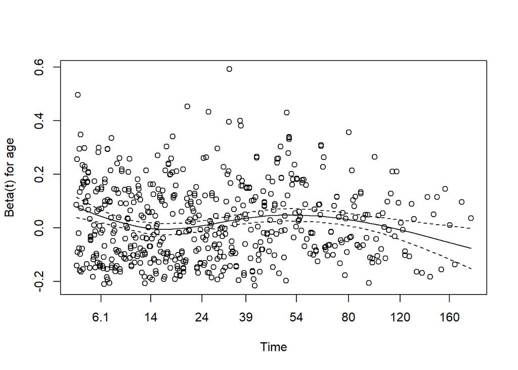

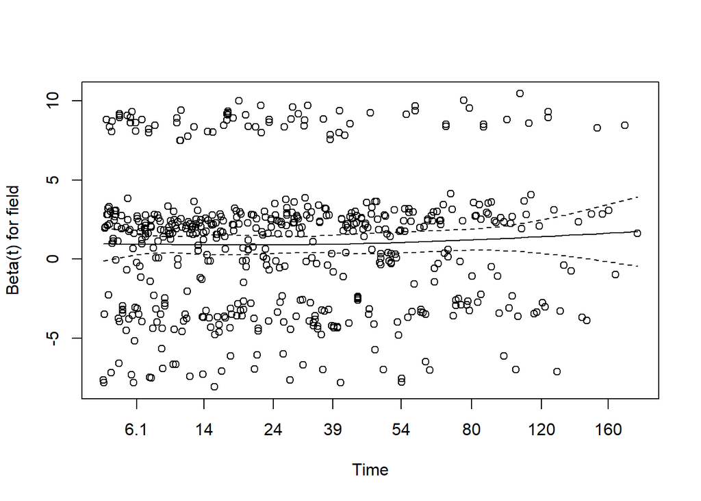

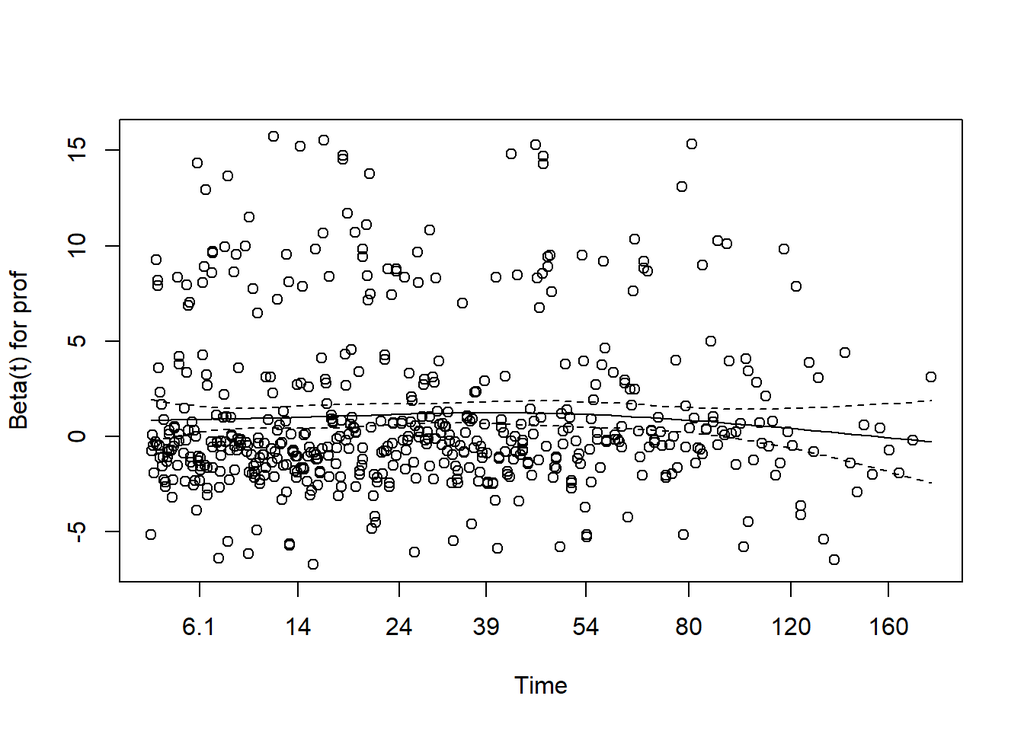

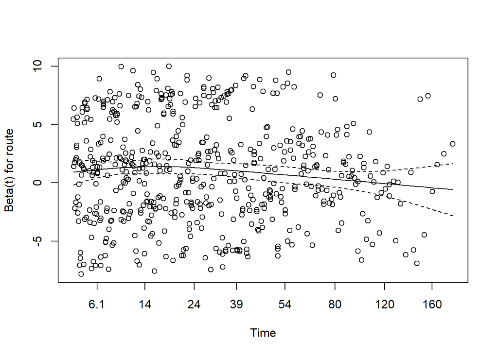

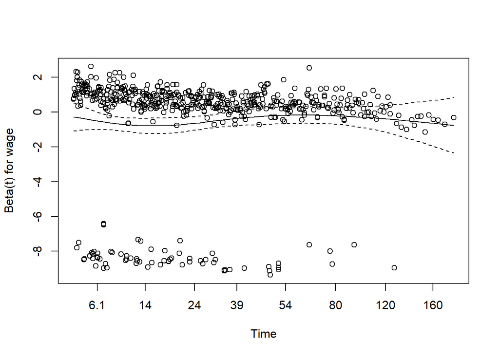

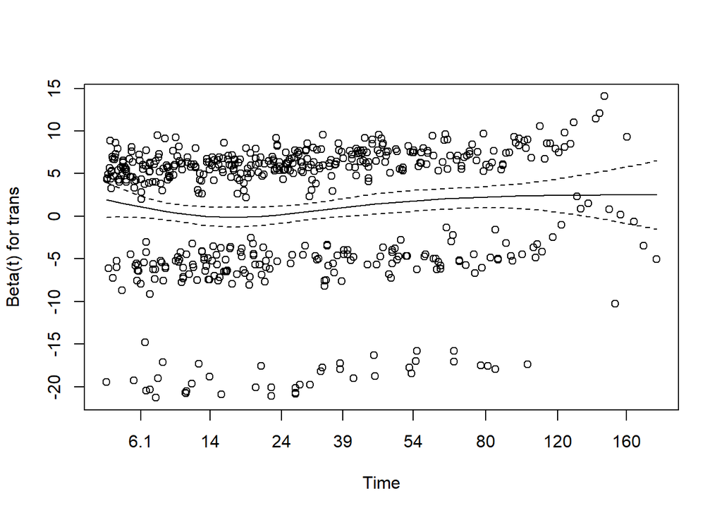

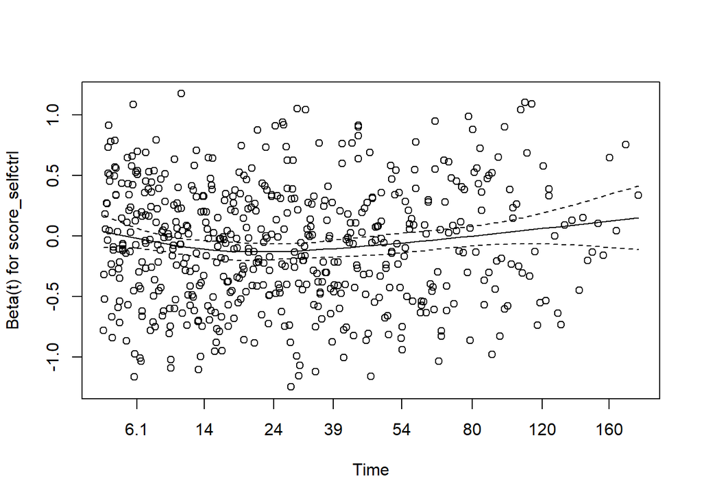

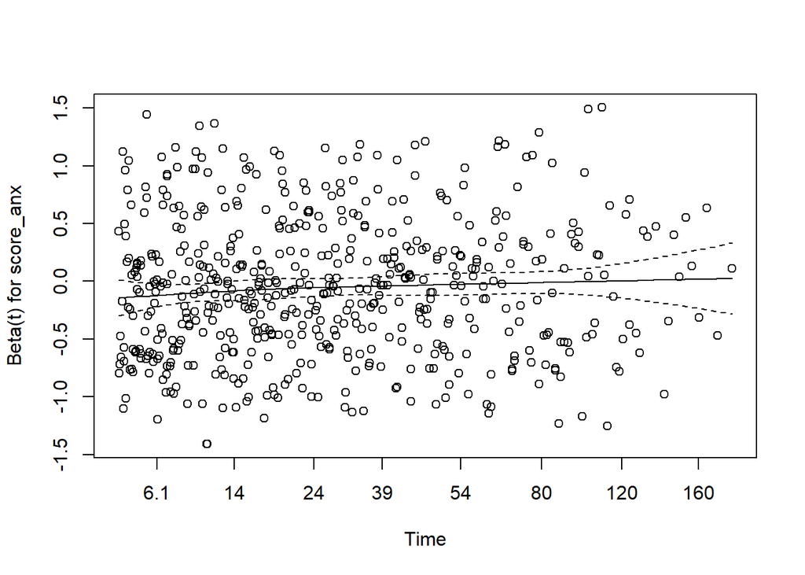

```r
plot(ph_test)
```

```r
# Stratify the model by the covariate that violates the assumption
cox_model_strat <- coxph(Surv(exp, event) ~ age + field + strata(prof) + route +
    wage + trans + score_selfctrl + score_anx, data = emp_df)
summary(cox_model_strat)
```

```
## Call:
## coxph(formula = Surv(exp, event) ~ age + field + strata(prof) +
##     route + wage + trans + score_selfctrl + score_anx, data = emp_df)
##
##   n= 1129, number of events= 571
##
##                          coef exp(coef)  se(coef)      z Pr(>|z|)
## age                  0.023977  1.024266  0.006529  3.672 0.000240 ***
## fieldfinance         0.351325  1.420950  0.139990  2.510 0.012085 *
## fieldIT             -0.517867  0.595790  0.195140 -2.654 0.007959 **
## fieldmanufacture    -0.200800  0.818076  0.147234 -1.364 0.172626
## fieldretail         -0.314352  0.730262  0.115144 -2.730 0.006332 **
## routefriends        -0.037390  0.963301  0.225313 -0.166 0.868199
## routejobsite_apply   0.433081  1.542001  0.177583  2.439 0.014738 *
## routejobsite_resume  0.682893  1.979596  0.180117  3.791 0.000150 ***
## routerecommend       0.249538  1.283432  0.168212  1.483 0.137948
## wagewhite           -0.469301  0.625440  0.133487 -3.516 0.000439 ***
## transcar            -0.171671  0.842257  0.100130 -1.714 0.086443 .
## transfoot           -0.421441  0.656100  0.176033 -2.394 0.016661 *
## score_selfctrl      -0.064877  0.937183  0.022436 -2.892 0.003833 **
## score_anx           -0.060366  0.941420  0.025798 -2.340 0.019285 *
## ---
## Signif. codes:  0 '***' 0.001 '**' 0.01 '*' 0.05 '.' 0.1 ' ' 1
##
##                     exp(coef) exp(-coef) lower .95 upper .95
## age                    1.0243     0.9763    1.0112    1.0375
## fieldfinance           1.4209     0.7038    1.0800    1.8696
## fieldIT                0.5958     1.6784    0.4064    0.8734
## fieldmanufacture       0.8181     1.2224    0.6130    1.0917
## fieldretail            0.7303     1.3694    0.5827    0.9151
## routefriends           0.9633     1.0381    0.6194    1.4981
## routejobsite_apply     1.5420     0.6485    1.0887    2.1840
## routejobsite_resume    1.9796     0.5052    1.3908    2.8177
## routerecommend         1.2834     0.7792    0.9230    1.7847
## wagewhite              0.6254     1.5989    0.4815    0.8125
## transcar               0.8423     1.1873    0.6922    1.0249
## transfoot              0.6561     1.5242    0.4647    0.9264
## score_selfctrl         0.9372     1.0670    0.8969    0.9793
## score_anx              0.9414     1.0622    0.8950    0.9902
##
## Concordance= 0.635  (se = 0.016 )
## Likelihood ratio test= 96.17  on 14 df,   p=3e-14
## Wald test            = 99.54  on 14 df,   p=6e-15
## Score (logrank) test = 101.5  on 14 df,   p=2e-15
```

After applying stratify for the *prof* variables, we have the proportional hazard assumption holds for the model.

```r
# Test the proportional hazards assumption
ph_test <- cox.zph(cox_model_strat)

# Print the test results
print(ph_test)
```

```
##                   chisq df     p
## age            2.48e-01  1 0.619
## field          1.04e+00  4 0.903
## route          8.47e+00  4 0.076
## wage           2.33e-01  1 0.629
## trans          1.06e+00  2 0.589
## score_selfctrl 4.82e-05  1 0.994
## score_anx      6.95e-01  1 0.404
## GLOBAL         1.30e+01 14 0.524
```